$\def \d \ensuremath{\mathbf{d}}$ $\def \e \ensuremath{\mathbf{e}}$ $\def \g \ensuremath{\mathbf{g}}$ $\def \I \ensuremath{\mathbf{I}}$ $\def \l \ensuremath{\mathbf{l}}$ $\def \M \ensuremath{\mathbf{M}}$ $\def \W \ensuremath{\mathbf{W}}$ $\def \Omegab \ensuremath{\boldsymbol{\Omega}}$

# Simulation Studies for Non-Parametric Sign Test

Bhargob Kakoty, Rajesh Karmakar, Maruf Alam Tarafdar

4/10/2020

# 1 Objective of our study

# 2 Methodology of our simulation study

We will draw random sample $\underline{X}=\left(X_1,X_2, \dots X_n\right)$ of size $n$ from distribution $F_0=F(x-\theta)$ where $F$ is continuous and has median $0$. Our null hypothesis of interest is $H_0:\theta =0$ against its three type of alternatives. The three alternatives give rises to left, right and both tailed test. The value of the sign statistic corresponding the selected random sample is given by $T(\underline{X})=\sum_{i=1}^{n} I(X_i>0)$. Under $H_0$, it has $Bin(n, \frac{1}{2})$ distribution. In case the distribution has a non zero median $m$, we rather compute $T(\underline{X}-m \mathbf{1_n})$.  
The process is replicated $k$ times. The number of replication in our case is $k=10000$. This results in $k$ observations from $Bin(n, 1-F(-\theta))$.  
Now, suppose $c_{\alpha}$ denote the critical point of the null distribution corresponding to level of significance $\alpha$. The proportion of $T$ values exceeding $c_{\alpha}$ will give the simulated size or power according as $\theta=0$ or $\theta \not =0$. Exactly similar methodology is followed when we simulate the size and power of parametric tests for testing location parameter.

# 3 Simulated size and power of sign statistic

## 3.1 Simulated size

Suppose we are drawing random samples from $N(0,1)$ distribution. Let us fix $n=10$, $\alpha=0.05$ and alternative hypothesis as right tailed. By applying the above procedure the simulated size is obtained in `R`. The output is given below:-

```
## [1] 0.011
```

which appears to be less than $0.05$ as we expect. The following table shows the simulated sizes for right, left and both tailed tests corresponding to $\alpha=0.05$ and different values of $n$ and $F$ being $N(0,1)$.

```
##   n right.tailed left.tailed   both
##  10       0.0105      0.0113 0.0192
##  20       0.0231      0.0179 0.0417
##  30       0.0495      0.0475 0.0400
##  40       0.0395      0.0412 0.0370
##  50       0.0317      0.0348 0.0361
##  60       0.0465      0.0490 0.0264
##  70       0.0346      0.0319 0.0392
```

As we can see that the simulated sizes are always less than $\alpha=0.05$, and sometimes are very close to $0.05$. The reason for coming most of the values less than $0.05$ lies in the fact that the critical points of the binomial distribution are sometimes chosen in such a way that the size is not exactly equal to $\alpha$ but in fact less than $\alpha$. However, there may be sampling fluctuations which may result in a simulated value greater than $0.05$. The next two figures are indication of the same situation for $\alpha=0.01$ and $\alpha=0.10$, while all other conditions being same as earlier.
$$\alpha=0.01$$

```
##   n right.tailed left.tailed   both
##  10       0.0017      0.0010 0.0017
##  20       0.0051      0.0041 0.0022
##  30       0.0092      0.0085 0.0065
##  40       0.0097      0.0088 0.0088
##  50       0.0068      0.0078 0.0069
##  60       0.0060      0.0062 0.0065
##  70       0.0056      0.0061 0.0059
```

$$\alpha=0.10$$

```
##   n right.tailed left.tailed   both
##  10       0.0556      0.0567 0.0191
##  20       0.0543      0.0570 0.0430
##  30       0.0505      0.0516 0.1027
##  40       0.0744      0.0760 0.0822
##  50       0.0621      0.0625 0.0656
##  60       0.0801      0.0726 0.0922
##  70       0.0925      0.0920 0.0726
```

As we pointed out, the simulated size is in fact greater than the value of $\alpha$ for the both tailed test corresponding $\alpha=0.10$ and $n=30$. All other values are less than the chosen size.

Next we present some graphical representations of how simulated size behaves as $n$ increases. The distribution from which samples are drawn is same as earlier ($N(0,1)$). The plots are presented for all the three tailed tests corresponding to each value of $\alpha=0.01, 0.05$ and $0.10$.

$$\alpha=0.01$$

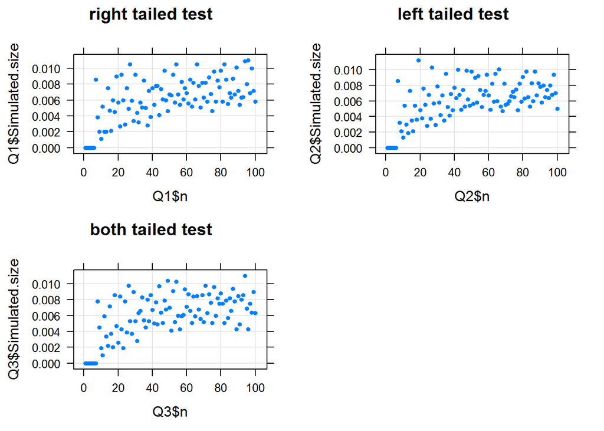

$$\alpha=0.05$$

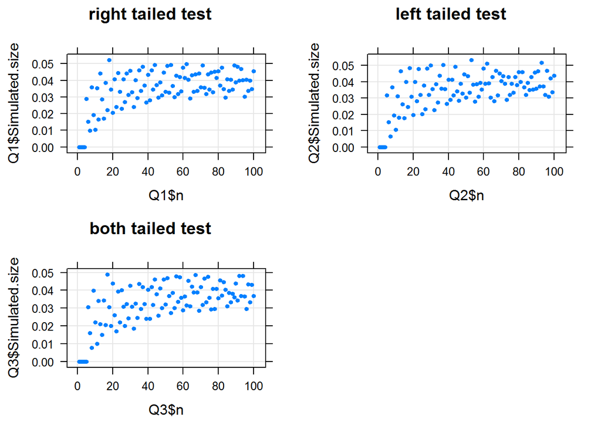

$$\alpha=0.10$$

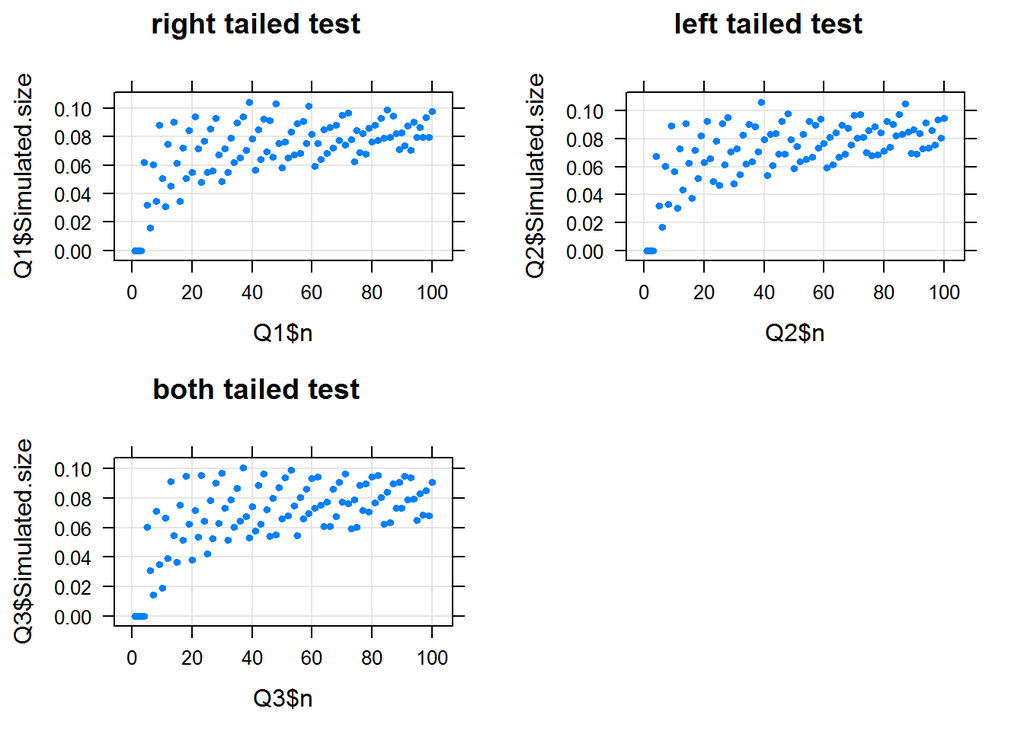

In all the plots we have seen an increasing pattern of the simulated sizes as n increases. For small values of $n$, the sizes are very much lower than the chosen $\alpha$. However, they tend closer to $\alpha$ for large values of $n$. It can be also seen that sometimes it exceed $\alpha$.
We can thus say that for large $n$, the simulated sizes becomes much more stable, in the sense that it is approaches $\alpha$. This in fact shows that the test is asymptotically size $\alpha$ test. Because if we consider the right tailed $% $ critical point of $Bin(n, \frac{1}{2})$ distribution as $k_n$, then the fact that sizes approach to $\alpha$ as $n$ increases can be mathematically represented as
$$lim_{n \to \infty}P(T_n>k_n) \to \alpha \qquad$$

where $T_n$ denote the sign statistic based on $n$ random observations.

We have considered only a specific distribution to show all the above results. The same thing can be performed when $F$ is not normal but other continuous distribution. However, as we will show in our later section, it appears that the null distribution of $T$ does not depend on $F$. Thus all the things we have done so far will not be affected by the choice of different $F$. Still, the nature of the simulated sizes and its behavior with $n$ can be seen from the shiny interactive link which we have shared in the section dealing with power of the test. We just have to choose $\theta_1=0$, the required $\alpha$ and the required distribution.

## 3.2 Simulated Power

In this section we will be dealing with the simulated power of the sign test. Our interest will be mainly of two aspects. Firstly we will study the behavior of power as a function of $n$, keeping $\theta_1$ (the value of $\theta$ under $H_1$ ) fixed. It will enable us to show its consistency. Secondly we will be treating power as function of $\theta_1$ (this time $n$ being fixed) and will see how it behaves as $\theta_1$ moves away from the value of $\theta$ under $H_0$. In our case, irrespective of the distribution $F$ we have considered, the value of $\theta$ under $H_0$ will be always $0$.

```
## [1] 0.3387
```

```
##     n Simulated.power
##    10          0.0204
##    20          0.0530
##    40          0.1333
##    80          0.2017
##   200          0.3319
##   300          0.4931
##   600          0.7425
##  1000          0.9123
##  1500          0.9770
##  2000          0.9949
```

We can see that as $n$ increases indefinitely, the power tends to $1$. This shows the consistency of the sign test. Below we present a graphical representation of the same fact:-

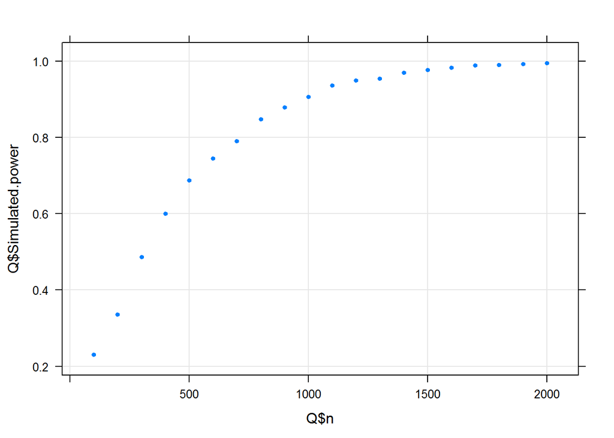

The unbiasedness and consistency both can be clearly explained from the above plot. The value of $n$ for which the simulated power is very close to $1$ will depend on $\theta_1$ chosen. It is expected that if $\theta_1$ is far away from the the null value (here $0$), then the convergence will be obtained from moderate values of $n$. For instance, under the above conditions and $\theta_1=0.7$ the values of simulated powers for different values of $n$ are given below:-

```
##    n Simulated.power
##   10          0.2455
##   20          0.6248
##   30          0.8939
##   40          0.9452
##   50          0.9745
##   60          0.9934
##   70          0.9956
##   80          0.9989
##   90          0.9997
##  100          1.0000
```

As opposed to the earlier case, the convergence to $1$, in this case, starts appearing from $n=50$ on wards. Similarly, we can show consistency for different values of $\theta_1$. In case of right tailed test we have to choose $\theta_1 > 0$ whereas for left tailed test the simulated power can be computed for $\theta_1<0$. For a both tailed test $\theta_1$ can be either less than or greater than $0$.  
For e.g., the simulated power of the test under the same $F$ as above, $n=20, \alpha=0.10$ but for a left tailed test and with $\theta_1=-0.3$ is given by

```
## [1] 0.3493
```

which again appears to be greater than $\alpha=0.10$. Similarly, for a two tailed test and for values of $\theta_1$ as $0.45$ and $-0.26$ the simulated powers are shown respectively:-

```
## [1] 0.3485
```

```
## [1] 0.1555
```

Whatever we have done so far is for $\alpha=0.05$ and $F$ being Laplace distribution. As we mentioned earlier, the choice of $F$ will not make any difference in the result. However, we can choose different $F$ and different $\alpha$ and can validate the above the results. We have created an interactive presentation of the above results for different $F$, different $\alpha$. different $\theta_1$ and all directions.  
The interactive presentation can be accessed via the following link :- https://bhargob30.shinyapps.io/bhargob5/

We can choose appropriate distribution, $\alpha$, the value of $\theta_1$ and direction which will result in a table and a plot showing the behavior of simulated power as $n$ increases. We can see that similar nature of power function is revealed in all the cases.

Our next aim is to study the behavior of power function with $\theta_1$. Let us fix this time $F$ as $U(-3, 3)$ distribution and $n=15$. Suppose we consider $\alpha=0.01$, and a left tailed test. The following table shows the simulated powers for different values of $\theta_1$

```
##  theta1 Simulated.power
##    -3.0          1.0000
##    -2.5          0.8770
##    -2.0          0.5336
##    -1.5          0.2338
##    -1.3          0.1496
##    -1.0          0.0751
##    -0.8          0.0490
##    -0.7          0.0381
##    -0.4          0.0140
##    -0.2          0.0081
##    -0.1          0.0054
```

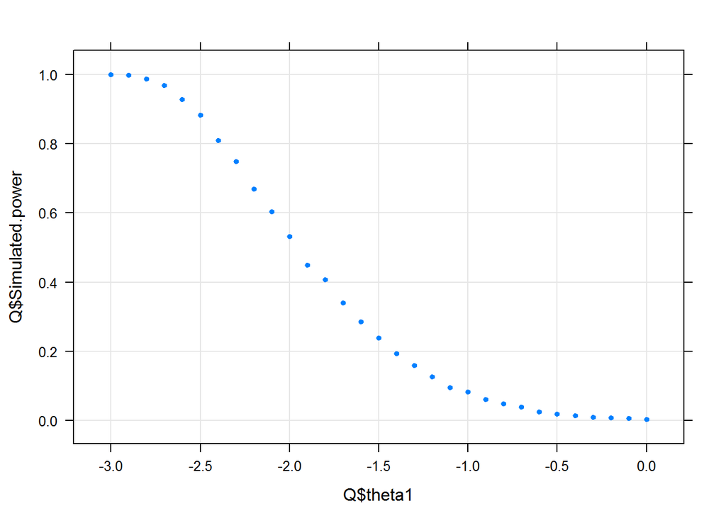

Let us now consider the same situation for but with higher values of $n$, say $50$. A table and plot of power versus $\theta_1$ are shown below:-

```
##  theta1 Simulated.power
##    -3.0          1.0000
##    -2.5          1.0000
##    -2.0          0.9979
##    -1.5          0.9057
##    -1.3          0.7672
##    -1.0          0.4875
##    -0.8          0.2984
##    -0.7          0.2183
##    -0.4          0.0661
##    -0.2          0.0252
##    -0.1          0.0137
```

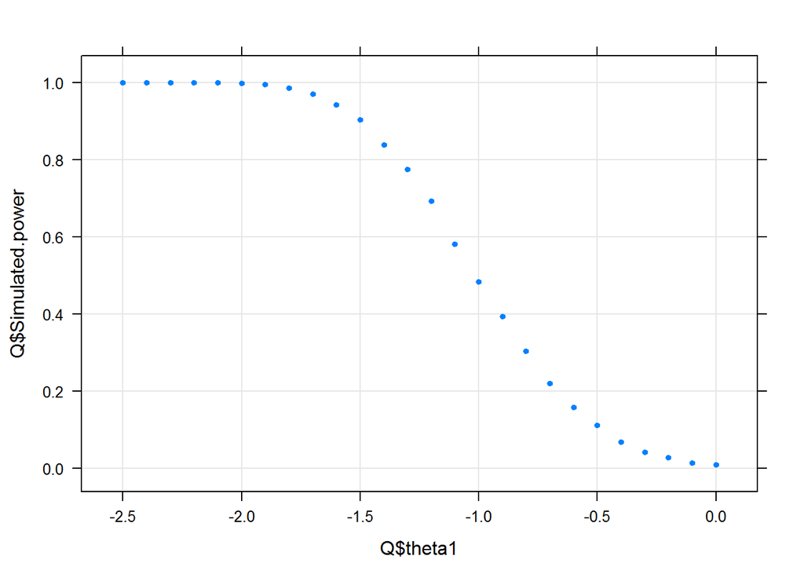

Next we show the simulated powers and a plot of power versus $\theta_1$ for a two tailed test and $n=15$ when all other parameters like $F$, $\alpha$ being same as above.

```
##  theta1 Simulated.power
##    -3.0          1.0000
##    -2.5          0.8770
##    -2.0          0.5336
##    -1.5          0.2338
##    -1.0          0.0767
##    -0.8          0.0429
##    -0.6          0.0275
##    -0.2          0.0096
##    -0.1          0.0070
##     0.1          0.0082
##     0.2          0.0092
##     0.6          0.0261
##     0.8          0.0430
##     1.0          0.0799
##     1.5          0.2390
##     2.0          0.5361
##     2.5          0.8723
##     3.0          1.0000
```

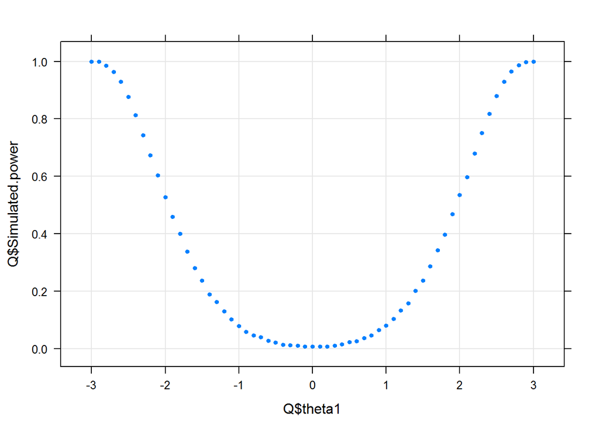

Similarly we can take choose $F , \alpha$, direction of the test, the value of $n$ in order to show similar kind of results. We have created an interactive presentation of the same in the following link:- https://bhargob30.shinyapps.io/bhargob6/

# 4 Distribution free nature of the sign statistic

## 4.1 Objectives

-Showing the null distribution of the sign statistic

$$T=\sum_{i=1}^{n}{I(X_{i}>0)}$$
is close to $Bin(n,\frac{1}{2})$ through simulation studies.

-Showing that the sign statistic is exactly distibution free.

-Showing that the sign statistic is asymptotically distribution free.

Here we give a sample output from exponential distribution after symmetrization obtained by subtracting from the median.

```
##              [,1]        [,2]        [,3]         [,4]         [,5]
## [1,]  0.008949709  0.31765568 0.100640667  0.049354131  0.241127443
## [2,]  0.070475018  0.07738831 0.009937669  0.170654664 -0.007394475
## [3,] -0.078978963 -0.02214022 0.078548451 -0.005540027 -0.057567398
## [4,] -0.079831807  0.03800352 0.538238796 -0.051390774 -0.018362861
## [5,] -0.037088596 -0.07878575 0.052138420 -0.015100322 -0.084696955
```

## 4.2 Distribution Free Nature of Sign Statistic

### 4.2.1 Pairwise Histograms

Firstly we sample from different absolutely continuous distributions with median 0 and and consider the histogram vs. histogram plot of S based on each pair of sample and see that they have the same distribution.

#### 4.2.1.1 Normal vs. Uniform for different values of n-

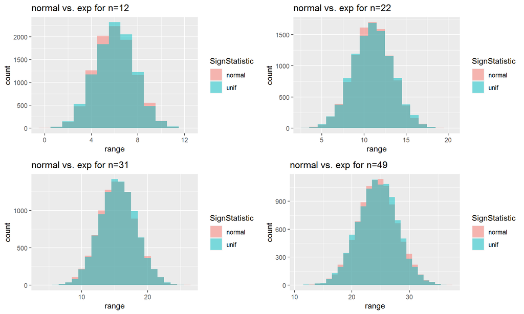

#### 4.2.1.2 Normal vs. Exponential for different values of n-

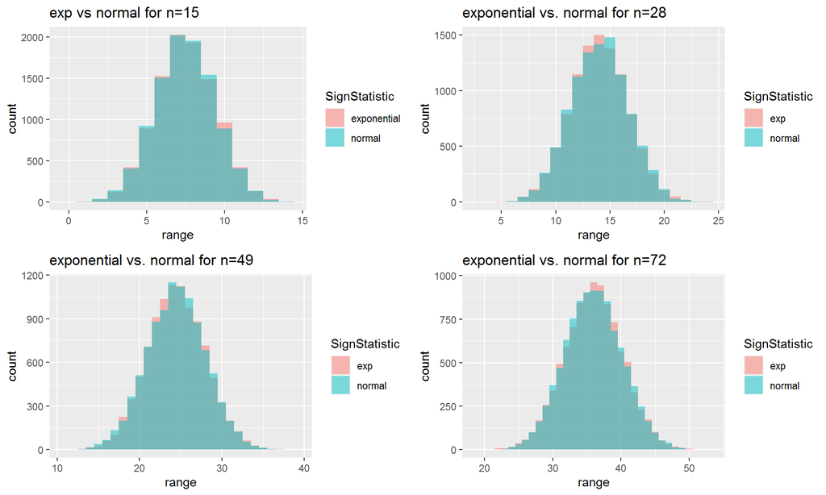

#### Exponential vs. Cauchy for different values of n-

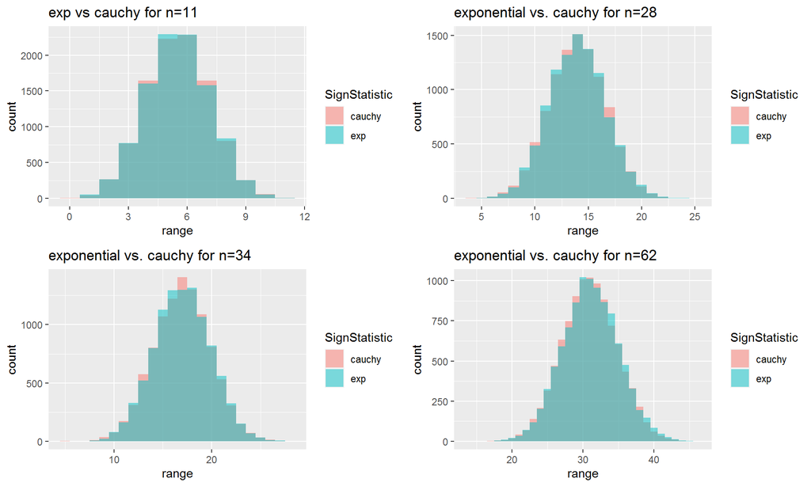

#### 4.2.1.3 Beta vs. Cauchy for different values of n-

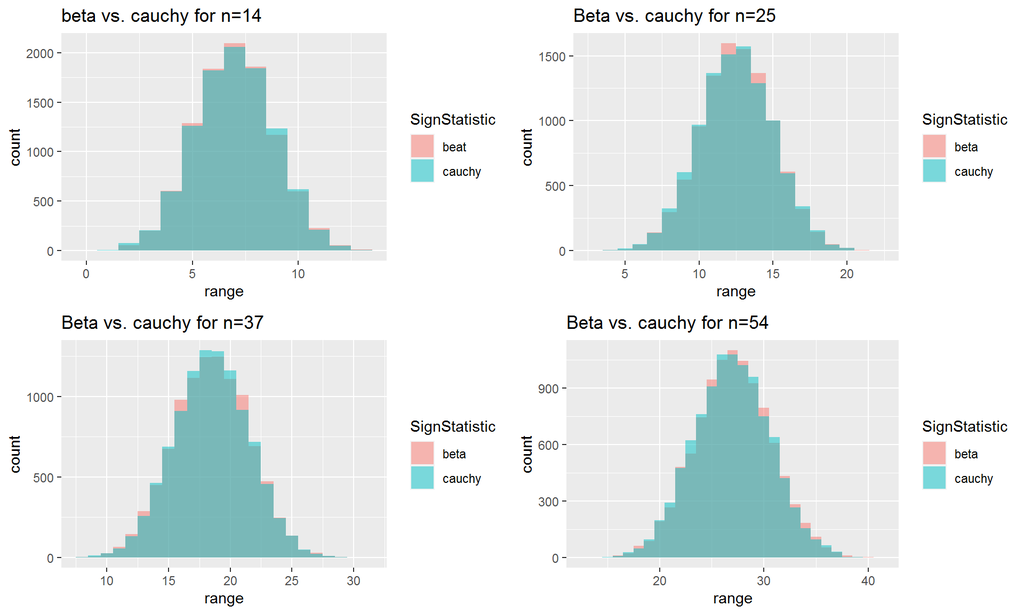

As we can obseve above that for five distributions and many pairs the histograms almost coincides with each other. This strenthens our claim that sign statistic is distribution free.

Below we give the pairwise q-q plot for sampling from different distributions.

### 4.2.2 pairwise Q-Q plots for diffetrent distributions

#### 4.2.2.1 Uniform vs Normal for different values of n-

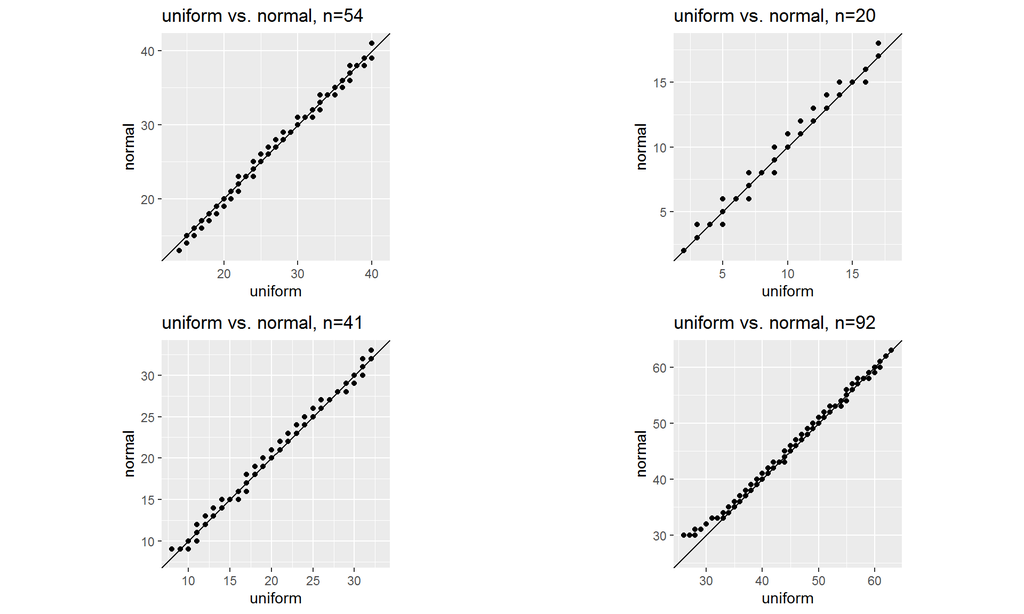

#### 4.2.2.2 Uniform vs Beta for different values of n-

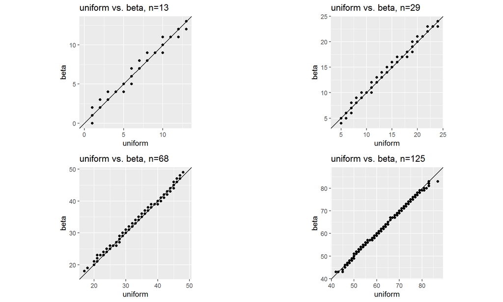

#### 4.2.2.3 Exponential vs Beta for different values of n-

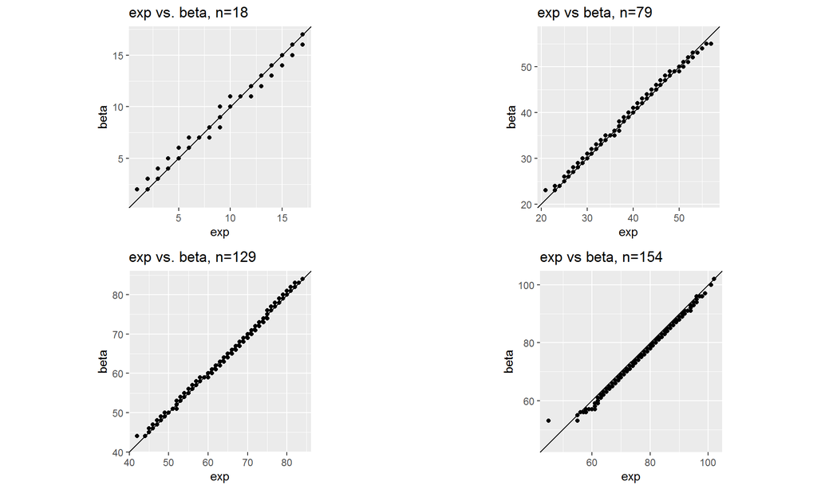

#### 4.2.2.4 exp vs cauchy for different values of n-

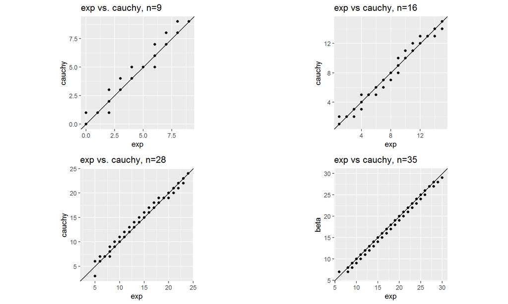

From all the above graphs, it is very easy to see that distribution of S is independent of the underlying distribution from which the sample is drawn.

## 4.3 Identifying the distribution of Sign Statistic

### 4.3.1 Histograms

#### 4.3.1.1 exponential distribution-

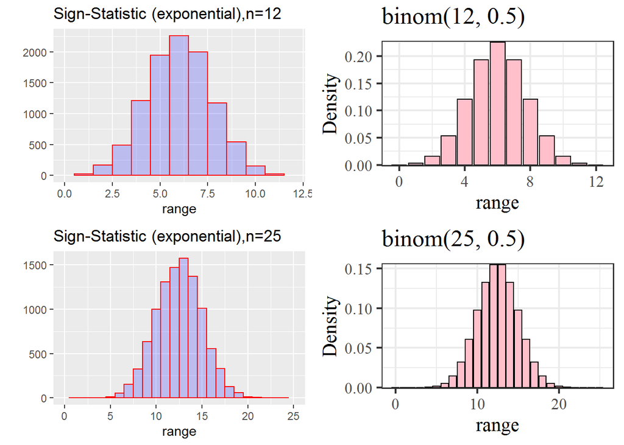

#### 4.3.1.2 uniform distribution-

In this case also as expected we get similar kind of graph for different values of $n$.

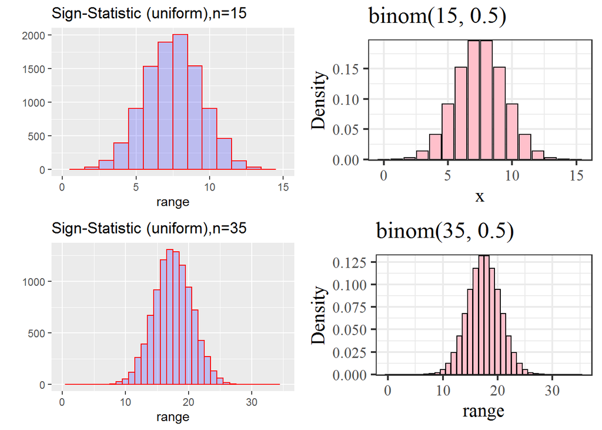

#### 4.3.1.3 Normal distribution-

In this case also as expected we get similar kind of graph for different values of $n$.

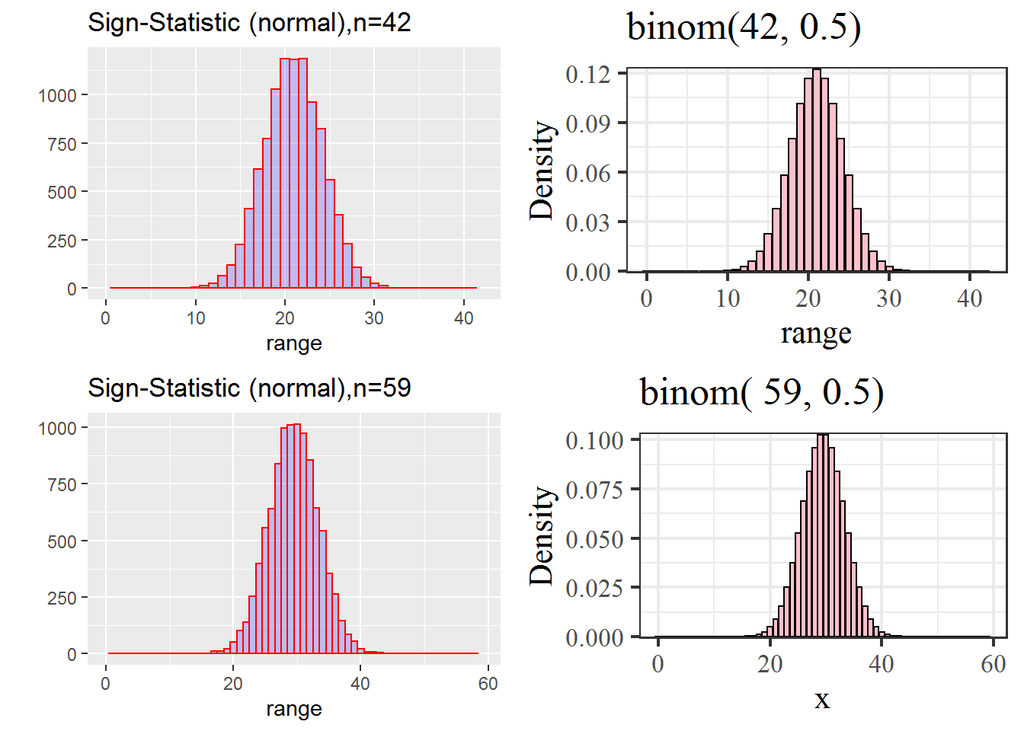

#### 4.3.1.4 beta distribution-

In this case also as expected we get similar kind of graph for different values of $n$.

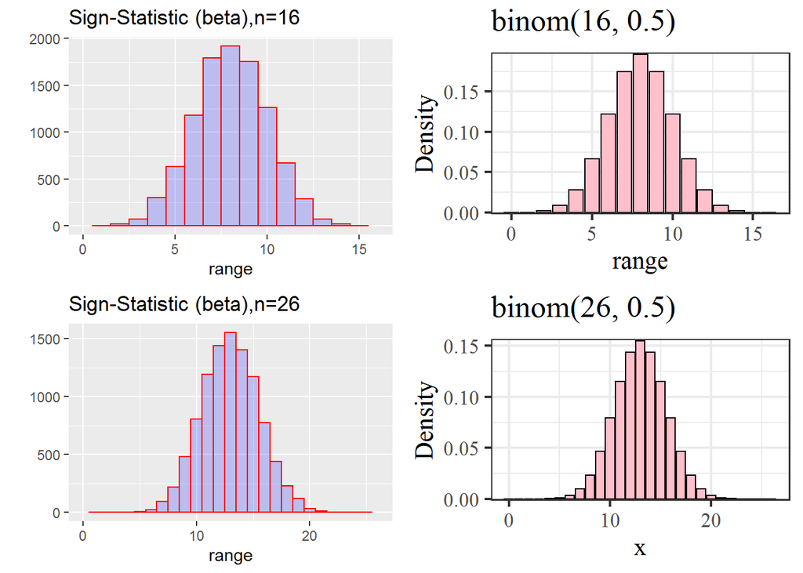

#### 4.3.1.5 cauchy distribution-

And in the final case also we get similar kind of graph for different values of $n$.

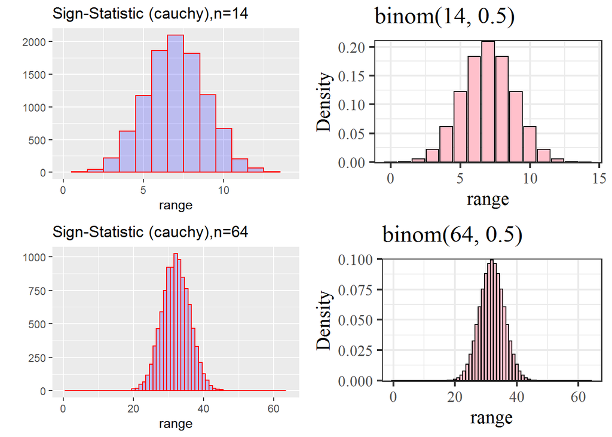

Above observations very strongly suggests that the null distribution of the sigh statistic is $B(n,\frac{1}{2})$.But to strengthen our claim more we plot the Q-Q plot of sample quantiles versus theoreical $Bin(n,\frac{1}{2})$ quantiles.

### 4.3.2 Q-Q Plots

#### 4.3.2.1 Uniform(Sample) quantile vs Binomial(theoretical) quantile for different values of n-

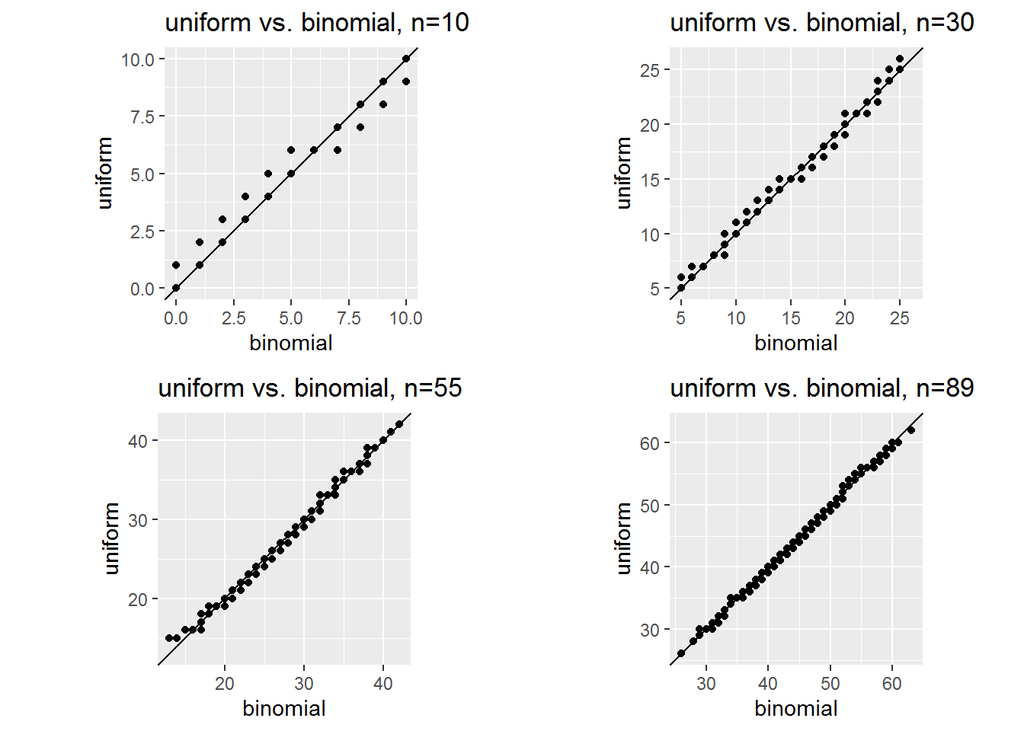

#### 4.3.2.2 Beta(Sample) quantile vs Binomial(theoretical) quantile for different values of n-

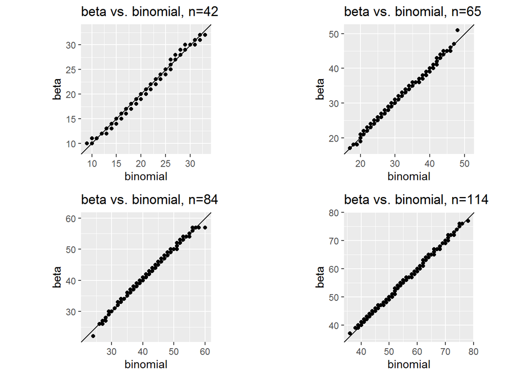

#### 4.3.2.3 Cauchy(Sample) quantile vs Binomial(theoretical) quantile for different values of n-

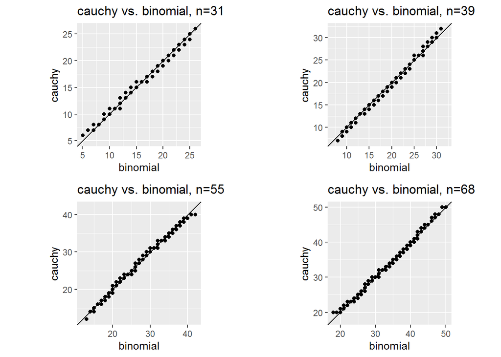

#### 4.3.2.4 Exponential(Sample) quantile vs Binomial(theoretical) quantile for different values of n-

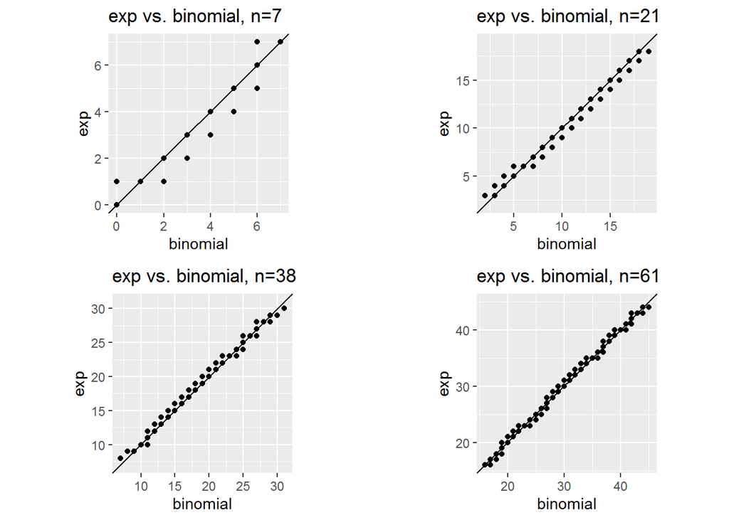

#### 4.3.2.5 Normal(Sample) quantile vs Binomial(theoretical) quantile for different values of n-

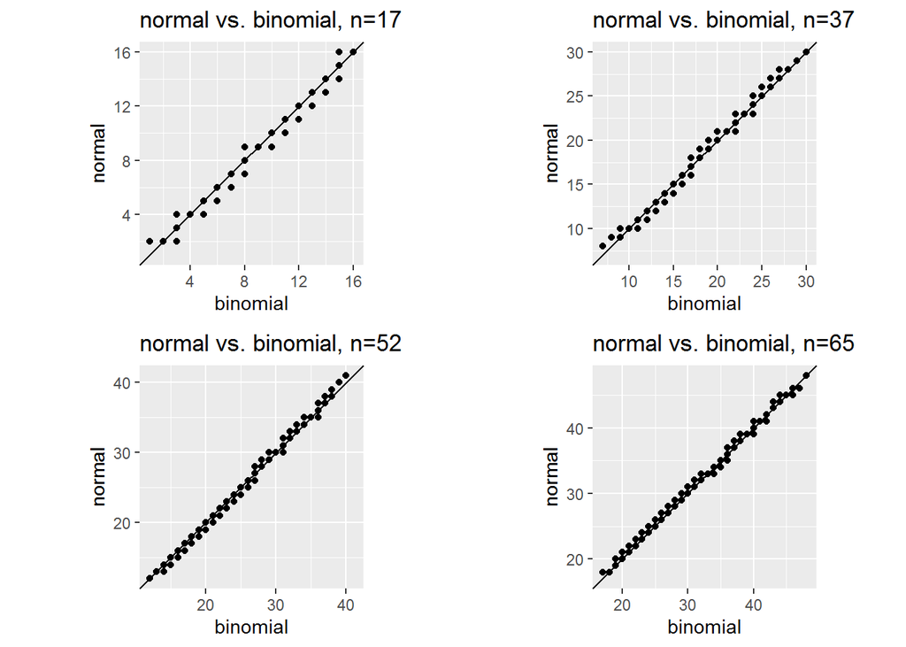

Clearly all the graphs above suggests that the distribution of the sign statistic is $Bin(n,\frac{1}{2})$.

## 4.4 Nature of Distribution of Sign Statistic Under Alternative

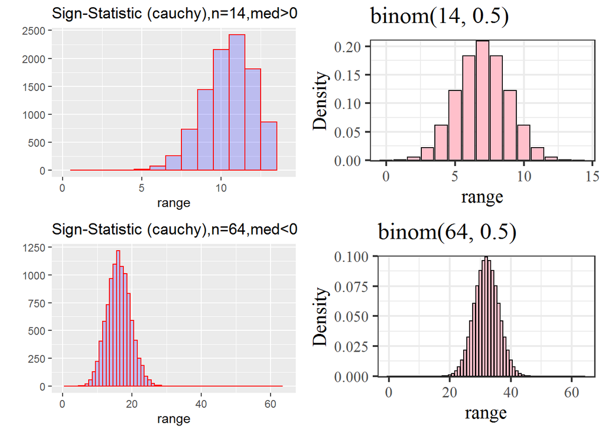

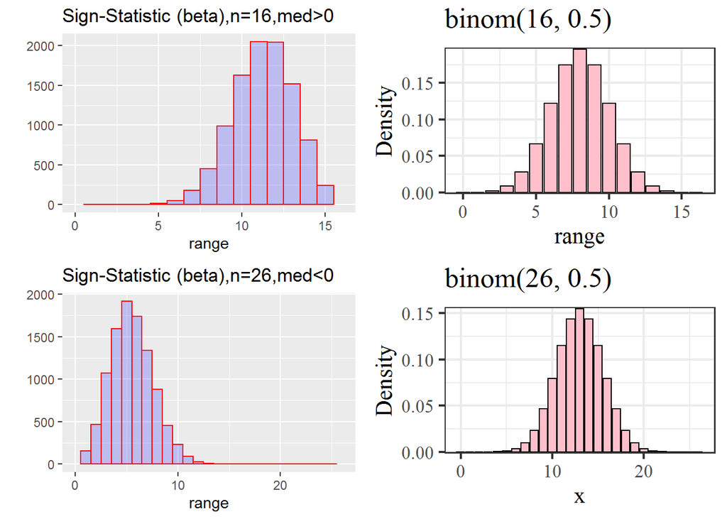

# 5 Asymptotic distribution free nature and limiting distribution

We have already shown that the sign statistic is distribution free. Here we will deal with the limiting distribution of the normalized version of the sign statistic. This limit is achieved irrespective of the choice of $F$, which we term as asymptotically distribution free nature. The normalized or standardized version of $T$ is given by :-

$$T'=\frac{T-\frac{n}{2}}{\sqrt{\frac{n}{4}}}=\frac{2T-n}{\sqrt{n}}$$

This converges to a $N(0,1)$ variate as $n \to \infty$. Firstly we will consider a density estimate obtained from the sample values of $T$ and will try to show that it approaches to the standard normal density as the number of observations increase. The density estimate we are going to consider is histogram. Suppose we take $F$ as weibull distribution with shape and scale parameter $1.5$ and $1$ respectively. Then for a sequence of increasing sequence of $n$, the histograms along with the normal density curve are shown below:-

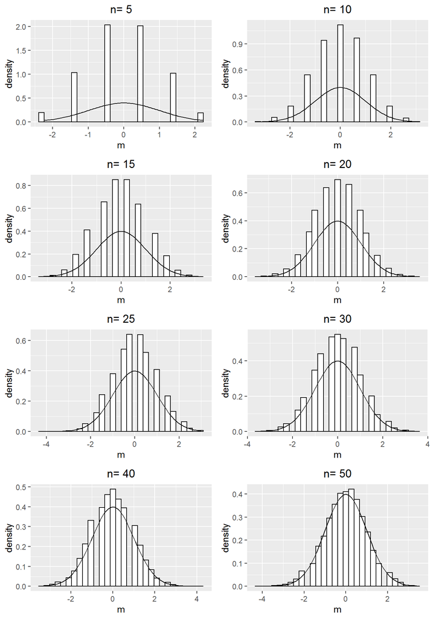

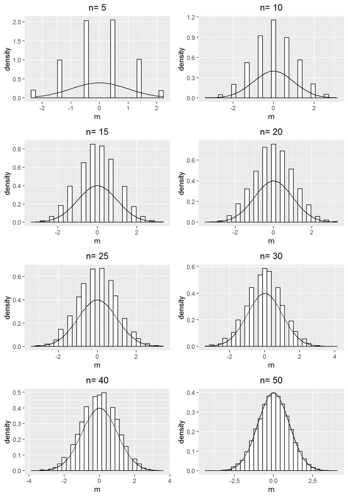

So similar results are obtained in this case too. We have made a `shiny` representation where we can make our choice of $F$ and $n$ and it shows the approximation of the histogram by normal curve. The application is accessible through the link :-https://bhargob30.shinyapps.io/bhargob/. For every other distribution we can see the results and it matches our claim that $T'$ converges to normal variate.